# [2019]_Горелов_Шарпей_I

# 8. ЭЛЕМЕНТ УПРАВЛЕНИЯ Button.

К управляющим элементам управления в первую очередь относится традиционная командная кнопка, представленная классом Button. Нажатие на кнопку (левой кнопкой мыши, клавишей Enter или ПРОБЕЛ, если кнопка имеет фокус), как правило, приводит к выполнению каких-либо вычислений. На рис. 8.1 показана форма с кнопками «Конвертировать» и «Выход». К наиболее используемым свойствам кнопки относятся ранее описанные свойства класса Control. Класс Button дополняет к унаследованным свойствам новые, отображаемые в окне «Свойства». Рассмотрим некоторые из них, тем более что аналогичные свойства есть и у многих других элементов управления. AutoSize — определяет, будет ли размер элемента управления автоматически изменяться в соответствии с размером его содержимого. Значение true, если размеры элемента управления автоматически изменяются в зависимости от его содержимого; в противном случае — значение false (значение по умолчанию). Если в процессе выполнения программы будет изменяться текст кнопки (свойство Text), то установите AutoSize = true, и размеры кнопки будут подстраиваться под размеры текста.

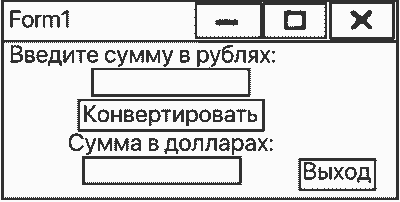

Рис. 8.1. Форма с кнопками «Конвертировать» и «Выход»

**TextAlign** - возвращает или задает способ выравнивания текста на кнопке. Возможные значения определяются перечислением System.Drawing.ContentAlignment:

- BottomCenter - содержимое выравнивается вертикально по нижнему краю и горизонтально по центру.
- BottomLeft — содержимое выравнивается вертикально по нижнему краю и горизонтально по левому краю.
- BottomRight - содержимое выравнивается вертикально по нижнему краю и горизонтально по правому краю.
- MiddleCenter — содержимое выравнивается вертикально по середине и горизонтально по центру.
- MiddleLeft — содержимое выравнивается вертикально по середине и горизонтально по левому краю.
- MiddleRight — содержимое выравнивается вертикально по середине и горизонтально по правому краю.
- TopCenter — содержимое выравнивается вертикально по верхнему краю и горизонтально по центру.

Страница 75

- TopLeft — содержимое выравнивается вертикально по верхнему краю и горизонтально по левому краю.
- TopRight - содержимое выравнивается вертикально по верхнему краю и горизонтально по правому краю.
- AutoEllipsis - получает или задает значение, указывающее, отображается ли знак многоточия (...) в правом углу элемента управления, если его текст вышел за пределы указанной ширины этого элемента управления.

**FlatStyle** — получает или задает внешний вид для кнопки. Возможные значения определяются одноименным Перечислением:

- Flat — элемент управления всегда выглядит плоским.
- Рорир — элемент управления выглядит плоским, а при наведении на него указателя мыши становится объемным.
- Standard — элемент управления выглядит объемным.
- System — внешний вид элемента управления определяется операционной системой Windows.

Страница 76

Такое же свойство, FlatStyle, есть и у классов RadioButton и CheckBox. FlatAppearance — для кнопок с FlatStyle, равным FlatStyle.Flat, определяет внешний вид границы и цвета, используемые для указания состояния, когда кнопка находится в фокусе и на неё наведён указатель мыши. Возможные значения свойства FlatAppearance задаются через точку следующими свойствами:

- BorderColor — получает или задает цвет границы вокруг кнопки.
- BorderSize - получает или задает значение, определяющее размер в пикселях для границы вокруг кнопки.
- CheckedBackColor — получает или задает цвет клиентской области кнопки, когда она нажата, и указатель мыши находится вне границ элемента управления.
- MouseDownBackColor - получает или задаст цвет клиентской области кнопки, когда нажата кнопка мыши, и указатель мыши находится в границах элемента управления.
- MouseDownBackColor - получает или задаст цвет клиентской области кнопки, когда нажата кнопка мыши, и указатель мыши находится в границах элемента управления.
- MouseOverBackColor — получает или задает цвет клиентской области кнопки, когда указатель мыши находится в границах элемента управления.
- Image — получает или задает изображение, отображаемое в кнопке. Это изображение рисуется поверх фонового изображения (см. BackGroundImage класса Control). Если свойство FlatStyle имеет значение FlatStyle.System, любые изображения, присвоенные свойству Image, не отображаются.

Страница 77

**ImageAlign** — получает или задает выравнивание изображения в кнопке. Возможные значения определяются перечислением System.Drawing.ContentAlignment:

- TopLeft — содержимое выравнивается вертикально по верхнему краю и горизонтально по левому краю.
- TopCenter — содержимое выравнивается вертикально по верхнему краю и горизонтально по центру.
- TopRight — содержимое выравнивается вертикально по верхнему краю и горизонтально по правому краю.
- MiddleLeft — содержимое выравнивается вертикально по середине и горизонтально по левому краю.
- MiddleCenter — содержимое выравнивается вертикально по середине и горизонтально по центру.
- MiddleRight — содержимое выравнивается вертикально по середине и горизонтально по правому краю.
- BottomLeft — содержимое выравнивается вертикально по нижнему краю и горизонтально по левому краю.
- BottomCenter - содержимое выравнивается вертикально по нижнему краю и горизонтально по центру.
- BottomRight — содержимое выравнивается вертикально по нижнему краю и горизонтально по правому краю.

Перечисленные значения выводятся на экран в графическом виде. Как следует из приведённого списка значений перечисления, для изображения, рисуемого поверх фона, имеется значительно больше возможностей по выравниванию по сравнению с фоновым изображением. Зато фоновое изображение может быть растянуто, обрезано и т. д. **ImageList** — получает или задает список изображений типа Image, из которого в элементе управления может быть отображено изображение с индексом (номером) ImageIndex. Это свойство является альтернативным свойству Image. Для того чтобы присвоить значение свойству ImageList, сначала перетащите на форму из Панели элементов компонент с аналогичным именем (ImageList). Если это первый компонент этого типа на форме, то он по умолчанию получит имя imageList1. Далее, используя свойство Images этого компонента, создайте список изображений. На рис. 8.2 показано окно Редактора коллекции изображений, в котором добавлено два изображения.

Страница 78

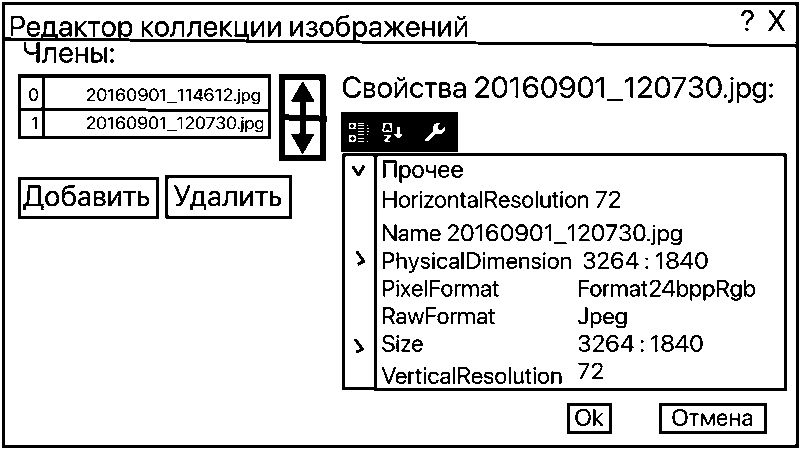

Рис. 8.2. Добавление изображений в коллекцию ImageList.

После того как список изображений создан, следует вернуться к элементу управления Button и выбрать свойство ImageList. Теперь Вы увидите, что этому свойству стал доступен для выбора ранее созданный компонент imageList1. Объект ImageList обычно используется такими элементами управления, как ListView, TreeView или ToolBar. Можно добавить точечные рисунки и значки в компонент ImageList, тогда другие элементы управления будут иметь возможность использовать эти изображения по мере необходимости. **ImageIndex** — получает или задает значение индекса (номера) изображения в списке изображений ImageList для отображения в кнопке. Свойства Image, ImageAlign, ImageList и ImageIndex имеют также и элементы управления Label, CheckBox, RadioButton, PictureBox и др.

Страница 79

DialogResult — это свойство будет рассмотрено в разделе, посвященном взаимодействию форм. Ряд элементов управления также имеют возможность быть нажатыми, поэтому они в своем составе имеют такие же свойства, как и элемент Button. При изучении этих элементов управления еще раз рассматриваться эти свойства, как правило, не будут.

Страница 80

# 9. ЭЛЕМЕНТ УПРАВЛЕНИЯ Label.

**Класс Label** представляет надпись. Этот элемент управления предназначен только для отображения текста. Вводить текст нельзя. В рассмотренном ранее приложении (см. рис. 2.8) результат конвертирования рублей в доллары мы отображали в элементе TextBox, сделав его доступным только для чтения (ReadOnly = true). **Такой выбор** был обусловлен только тем, что TextBox имеет рамку (границу) фиксированного размера, в то время как у Label по умолчанию рамка отсутствует. Однако у Label есть свойство BorderStyle, позволяющее нарисовать рамку (границу), при этом её размер будет определяться длиной текста, в то время как у TextBox ширина рамки устанавливается разработчиком.

**Удалите с формы** (см. рис. 2.8) элемент textBox2 и вместо него добавьте Label: получим объект label3. В обработчике button1_Click замените textBox2 на label3. Измените у label3 параметры текста (свойство Font), выберите для цвета фона (свойство BackColor) значение HighlightText и в свойстве Text установите значение " ". Получите форму, изображенную на рис. 9.1. **Как видите**, форма с элементом textBox2 (см. рис. 2.8) выглядит лучше, поэтому элемент управления Label в основном используется для вывода надписей, пояснений, комментариев и различных сообщений, например об ошибках. Кроме отображения текста, в элементе управления Label также может отображаться изображение с помощью свойства Image или сочетания свойств ImageList и ImageIndex. Элемент управления Label можно сделать прозрачным путем установки для его свойства BackColor значения Color. Transparent.

Страница 81

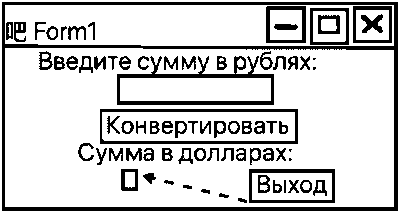

Рис. 9.1. Форма с элементом label3

Ряд свойств элемента управления Label аналогичны свойствам элемента Button. К уникальным свойствам, отображаемым в окне «Свойства», можно отнести свойство BorderStyle, которое возвращает или задает стиль границы для элемента управления. Значениями этого свойства являются следующие члены одноименного перечисления: **во-первых**, None — нет границы; **во-вторых**, FixedSingle — одинарная граница; **в-третьих**, Fixed3D — трехмерная граница. И последнее: элемент управления Label не получает фокус.

Страница 82

# 10. ЭЛЕМЕНТ УПРАВЛЕНИЯ TextBox.

Элемент управления TextBox обычно используется для ввода, отображения и редактирования текста. Текст, отображаемый в элементе управления, содержится в свойстве Text. Элемент управления TextBox обладает дополнительными функциональными возможностями, отсутствующими у элемента управления Label, включая ввод и редактирование текста, использование многострочного режима и маскировку знаков пароля. Для редактирования текста используются стандартные возможности: выделение части или всего текста, удаление отдельного символа или выделенной части (Del, Backspace), перемещение по тексту (стрелки, Home, End и др.). С помощью клавиш Ctrl-C и Ctrl-Х из текстового поля можно копировать и, соответственно, вырезать выделенный текст в буфер обмена. Комбинация Ctrl-V позволяет вставить из буфера обмена текст в поле TextBox. Перечислим ряд свойств элемента управления TextBox, отображаемых в окне «Свойства».

- AcceptsReturn — получает или задает значение, указывающее, какое действие необходимо выполнить в многострочном элементе управления TextBox при нажатии клавиши ENTER — создать новую строку текста или ничего не делать, активируя кнопку стандартного действия формы.
- HideSelection - получает или задает значение, показывающее, остается ли выбранный текст в поле выбранным, когда фокус ввода на форме переходит с данного элемента управления на другой.
- MaxLength — получает или задает максимальное число знаков, которое разрешается вводить или вставлять в элемент управления TextBox.

Страница 83

- Multiline — получает или задает значение, показывающее, является ли данный элемент управления многострочным TextBox.
- ScrollBars — получает или задает значение, показывающее, какие полосы прокрутки должны присутствовать в многострочном элементе управления TextBox.
- Lines — получает или задает массив строк текста в элементе управления TextBox. Каждый элемент массива становится строой текста в текстовом поле. Если для свойства Multiline элемента правления TextBox установлено значение true, и в тексте появляется знак перехода на новую строку, следующий за этим знаком текст добавляется в массив как новый элемент и отображается на отдельной строке.
- PasswordChar — получает или задает символ, используемый для маскировки символов пароля при их вводе в однострочный элемент управления TextBox.
- PreferredHeight — получает предпочтительную высоту текстового поля.
- ReadOnly — получает или задает значение, указывающее, является ли текст в текстовом поле доступным только для чтения.
- TextLength - получает длину текста в элементе управления.
- WordWrap - показывает, переносятся ли автоматически в начало следующей строки слова текста по достижении границы многострочного текстового поля.

Страница 84

**Такие свойства, как Text или TextAlign**, здесь не приведены, так как были описаны ранее. Также в классе TextBox имеется несколько полезных свойств, **неотображаемых в окне «Свойства»**. Вот список некоторых из них:

- CanUndo — получает значение, показывающее, может ли пользователь отменить предыдущую операцию в элементе управления TextBox.
- Modified — получает или задает значение, которое показывает, что содержимое элемента управления TextBox было изменено пользователем со времени создания элемента управления или последнего ввода его содержимого.
- SelectedText — получает или задает значение, показывающее текст, выбранный в текущий момент в элементе управления. Выбранный текст выделяется цветом. Путем присвоения нового текста этому свойству можно изменять текст, выбранный в текущий момент в текстовом поле. Если в данный момент в текстовом поле выбранного текста нет, это свойство возвращает строку ну левой длины.
- SelectionLength — получает или задает число символов, выбранных в текстовом поле.
- SelectionStart - получает или задает начальную позицию текста, выбранного в текстовом поле.

Поскольку в элемент управления TextBox можно вводить и редактировать текст, в классе был создан ряд специальных методов, поддерживающих эти возможности:

- **AppendText** - добавляет текст в конец текущего текста в текстовом поле.
- **Clear** — удаляет весь текст из текстового поля.
- **GetCharFromPosition** - извлекает символ, ближайший к указанному местоположению в элементе управления.
- **GetFirstCharIndexFromLine** - извлекает индекс первого символа заданной строки.
- **GetFirstCharIndexOfCurrentLine** - извлекает индекс первого символа текущей строки.
- **GetLineFromCharIndex** — извлекает номер строки по указанному местоположению символа в тексте элемента управления.
- **GetLineFromCharIndex** — извлекает номер строки по указанному местоположению символа в тексте элемента управления.
- **GetPositionFromCharIndex** — извлекает местоположение в элементе управления по указанному индексу символа.
- **Сору** — копирует текущий выбор из текстового поля в буфер обмена.
- **Paste()** — заменяет текущий выбор в текстовом поле содержимым буфера обмена. Буфер обмена не очищается.
- **Paste(String)** - устанавливает выделенный текст равным заданному тексту.
- **ScrollToCaret** — прокручивает содержимое элемента управления до текущей позиции точки вставки.
- **Select** — активирует элемент управления, выбирая в текстовом поле весь текст и выделяя его цветом.
- **Select(int start, int length)** — выбирает в текстовом поле подстроку размером /ength, начиная с позиции start. Цветом выбранная подстрока не выделяется.
- **SelectAll()** — выбирает в текстовом поле весь текст. Цветом выбранный текст не выделяется.
- **DeselectAll** — отменяет ранее выполненный выбор и выделение текста, указывая, что значение свойства SelectionLength равно нулю.
- **Undo** — отменяет последнюю операцию редактирования в текстовом поле.
- **ClearUndo** - удаляет из буфера обмена текстового поля сведения относительно последней операции.

Страница 85

Некоторые из перечисленных выше свойств и методов будут рассмотрены подробно. Поскольку TextBox отображает текст, то с ним можно работать, применяя все методы и свойства типа String. В элементе управления TextBox можно вводить или отображать текст только в одном формате, например, нельзя часть текста вывести курсивом. Для отображения текста в различных форматах следует использовать элемент управления RichTextBox. Чтобы вводить данные в текстовое поле в соответствии с маской, следует использовать элемент управления MaskedTextBox. По умолчанию в элементе управления ТехВох отображается одна строка текста без полос прокрутки. В однострочное текстовое поле можно ввести до 2048 знаков. Но если свойству MultiLine присвоить значение true, то в TextBox можно вводить и отображать несколько строк текста. Многострочный ТехВох позволяет вводить до 32 килобайт текста. Высота однострочного TextBox определяется размером шрифта, и ее нельзя изменить с помощью мыши. Высота многострочного элемента управления зависит от количества строк, и ее можно менять мышью (или свойством Size).

Страница 86

Поскольку строк в многострочном TextBox может быть много и их длина может быть достаточно большой, то возникает необходимость использования полос прокрутки, которые можно определить свойством ScrollBars. Значения этого свойства: во-первых, None — полосы прокрутки не отображаются; во-вторых, Horizontal — отображаются только горизонтальные полосы прокрутки; в-третьих, Vertical — отображаются только вертикальные полосы прокрутки; в-четвёртых, Both — отображаются и горизонтальные, и вертикальные полосы прокрутки. В однострочном поле, если длина текста превышает размер доступного пространства, отображается лишь часть текста. В многострочном поле (MultiLine = true) эту стандартную настройку можно изменить, присваивая соответствующие значения свойствам WordWrap и ScrollBars. WordWrap показывает, переносятся ли автоматически в начало следующей строки слова текста по достижении границы многострочного текстового поля. Однако, если WordWrap = true, то горизонтальная прокрутка не отображается, даже если она задана. При вводе текста в многострочное поле можно использовать клавиши Enter и Tab. Однако за этими клавишами стандартно закреплены другие функции. Чтобы их переопределить, можно использовать свойства AcceptsReturn и AcceptsTab.

**AcceptsReturn** — возвращает или задает значение, указывающее, что происходит при нажатии клавиши Enter в многострочном элементе управления TextBox: **во-первых**, создается новая строка текста (true); **во-вторых**, активируется кнопка Button, определенная для формы как кнопка приема данных (false).

Страница 87

AcceptsTab — возвращает или задает значение, указывающее, что происходит при нажатии клавиши Tab в многострочном элементе управления: во-первых, вводится знак табуляции в текстовом поле (true); во-вторых, фокус ввода в форме перемещается к следующему элементу управления в порядке табуляции (false). В следующем примере определяются свойства многострочного элемента управления textBox1 с вертикальной и горизонтальной полосами прокрутки.

```
textBox1.Multiline = true;
textBox1. WordWrap = false;
textBox1.ScrollBars = ScrollBars.Both;
textBox1.AcceptsReturn = true;
textBox1.AcceptsTab = true;
textBox1.Text = "Это многострочное поле!";
```

Для прокрутки содержимого элемента управления до тех пор, пока точка вставки (курсор) не появится в видимой области элемента управления, можно использовать метод `ScrollToCaret`.

**Для добавления новой строки в многострочный TextBox** необходимо использовать управляющие символы «Возврат каретки» (`\r`) и «Новая строка» (`\n`). Пример.

```
textBox1.Text = "Строка 1\r\ пстрока 2\r\n строка 3\r\n";
textBox1.Text += "Строка 4\r\n";
```

Добавленные строки в многострочном поле ввода выделяются цветом. Чтобы сбросить выделение, выполните оператор: `textBox1.SelectionStart = 0;`

**Если Вы хотите** отображать данные в виде таблицы, в которой столбцы должны быть выравнены по вертикали, рекомендуется для текста использовать моноширинный шрифт, например `Lucida Console`. Также каждое табличное поле нужно выровнять до единой ширины либо с помощью метода `string.Format`, либо с помощью методов `string.PadRight` или `string.PadLeft`.

Страница 88

**Добавление текста в конец однострочного поля**. Добавить текст в конец текстового поля программным путем можно разными способами. **Во-первых**, используя метод AppendText(): `textBox1.AppendText("Добавляем текст");` **Во-вторых**, используя оператор присваивания:

```
textBox1.Text += " Добавляем текст";
textBox1.Text += " Еще раз добавляем текст" ;
```

В однострочном поле не следует использовать управляющие символы, так как они будут отображаться как и другие, то есть как два символа. **Очистка поля**. Очистить поле можно, выделив весь текст и нажав клавишу Del. Но если текст слишком длинный, рекомендуется использовать отдельную кнопку. Эта кнопка может выглядеть в виде маленького значка, например (Картинка крестик), по щелчку которого в обработчике события Click может быть выполнен оператор `textBox1.Text = "";`

**Проверка введенного значения**. Существует несколько способов проверки введенного значения. **Способ 1**. Как правило, чтение введенных в текстовое поле данных перед их использованием осуществляется по кнопке `Button` (в обработчике события `Click`), поэтому самым очевидным решением для проверки типа является использование метода `TryParse` или `Parse`. В этом же обработчике можно проверить введенную величину на непротиворечивость физическому смыслу. **Пример**. Выполним проверку текстового поля с числовым значением перед его использованием. Приведенный ниже пример взят из раздела 2.1 и дополнен еще одной проверкой.

Страница 89

```
private void button1_Click(object sender, EventArgs e)
{
    float rubli, dollars;
    if (
        !float. TryParse(textBox1. Text, out rubli)
        || rubli <= 0
        || rubli >= 100000
    )
    {
        MessageBox.Show("неправильно введена сумма в рублях!");
        textBox1.Focus();
        return;
    }
    dollars = rubli / 50;
    textBox2.Text = dollars.ToString();
}
```

Если значение текстового поля в вышеприведенном примере не соответствует формату вещественного числа или его величине, то выводится сообщение об ошибке, и фокус передается элементу с ошибкой. При вводе вещественных чисел пользователь часто вместо запятой, отделяющей дробную часть от целой, использует точку. Исправим эту ошибку, не выдавая сообщения: `textBox1.Text = textBox1.Text.Replace('.', ',');`. Если текстовое поле должно содержать символьную строку, отличную от пустого значения, то для проверки можно воспользоваться свойством `string.Empty`.:

```
if (textBox1.Text.Trim() == string.Empty )
{
    MessageBox.Show("Введите значение в текстовое поле");
    textBox1.Focus();
    return;
}
```

Страница 90

В данном примере поле сначала очищается от пробелов методом Trim, так как пробел — это уже непустое значение, и лишь затем проверяется на пустое значение. Способ 2. Для проверки введенного значения можно использовать обработчик события Validating. Обработчик будет получать управление при потере элементом управления фокуса ввода, поэтому специальная кнопка не требуется. Событие Validating позволяет работать с клавиатурой, но блокирует другие действия пользователя, то есть не дает переключиться на другие элементы управления, пока не будет исправлена ошибка. Этим процессом управляет свойство Cancel параметра е обработчика события. Свойство e.Cancel получает или задает значение, показывающее, следует ли отменить событие. Если e.Cancel = true, то фокус ввода не покинет элемент управления, сгенерировавший это событие, до тех пор, пока не будет установлено е.Cancel = false. По умолчанию e.Cancel = false.

Пример обработчика события Validating:

```
private void textBox1_Validating(object sender, CancelEventArgs e)
{
    double x;
    if (textBox1 Text == "" || double.TryParse(textBox1.Text, out x))
    {e.Cancel = false;{
    else
    {
        e.Cancel = true;
        label10.Text = "Поле не может содержать буквы";
    }
}
```

Страница 91

**Способ 3**. Проверка символов в процессе их ввода. Для проверки вводимых значений можно использовать обработчик события `KeyPress`, который получает управление при нажатии любой клавиши клавиатуры в поле TextBox. В обработчике события `KeyPress` часть клавиатуры блокируется, но мышь работает.

**Пример**. Нижеприведенный обработчик события KeyPress разрешает вводить только числа и использовать управляющие клавиши (`Backspace`, `Del`, стрелки и др.) для редактирования числа. В противном случае устанавливается `e.Handled = true`, и ввод игнорируется. Кроме того, в надписи `label1` отображается сообщение об ошибке. Код обработчика:

```
private void textBox1_KeyPress(object sender, KeyPressEventArgs e)
{
    label1. Text = "";
    if (
        !char.IsDigit(e.KeyChar)
        && (!char.IsControl(e.KeyChar))
    )
    {
        e.Handled = true; // Запретить отображение символа
        label1.Text = "Поле не может содержать буквы";
    }
}
```

Особенностью способа является то, что проверяется только текущий символ, а не всё значение. В обработчике события `KeyPress` можно «отлавливать» нажатие таких управляющих клавиш, как `Enter`, `Esc` и `Backspace`. Что при этом делать, решает программист. В следующем примере для элемента управления `TextBox` используется свойство `e.KeyChar` события `KeyPress` для проверки нажатия клавиши Esc. Если эта клавиша нажата, то поле очищается, а свойство Handled получает значение true, которое указывает на то, что событие обработано.

```
private void textBox1_KeyPress(object sender, KeyPressEventArgs e)
{
    if (e.KeyChar == (char)Keys.Escape)
    {
        textBox1.Text = ""; // Очистить текстовое поле.
        e.Handled = true;
    }
}
```

Страница 92

```
textBox1.Text = "";
textBox1.PasswordChar = '*';
textBox1.MaxLength = 14;
```

**Теперь все** вводимые символы пароля будут отображаться в виде звездочек. Но это на экране, а в программе свойство Text будет содержать введенный пароль. Свойство `CharacterCasing` может использоваться для изменения регистра знаков, если это требуется в ходе работы приложения. Например, можно переводить в верхний или нижний регистр все знаки, вводимые в элемент управления TextBox, в соответствии с политикой, установленной для паролей.

Страница 93

Возможные значения свойства CharacterCasing: **во-первых**, Normal — регистр знаков не изменен; **во-вторых**, Upper — преобразует все знаки в прописные; **в-третьих**, Lower — преобразует все знаки в строчные. **Пример**. В следующем фрагменте кода для ввода пароля используется элемент управления `textBox1` типа `TextBox`. Свойство `CharacterCasing` служит для перевода всех символов пароля в нижний регистр, а свойство `MaxLength` — для ограничения длины пароля десятью знаками. Свойство `TextAlign` используется для выравнивания пароля по центру в элементе управления `textBox1`.

```
textBox1.MaxLength = 10;
textBox1.PasswordChar = '*';
textBox1.CharacterCasing = CharacterCasing.Lower;
textBox1.TextAlign = HorizontalAlignment.Center;
```

**Работа с выделенным текстом**. Для выборки всего текста или его подстроки можно использовать соответственно методы **SelectAll** и **Select**. Прочитать или изменить выбранный текст можно с помощью свойства SelectedText. Определить начало выбранного текста и его длину можно соответственно с помощью свойств SelectionStart и SelectionLength. Причем, если в элементе управления выбранный текст отсутствует, то свойство SelectionStart указывает место ввода (точку вставки) нового текста. Используя указанные свойства и методы, можно создать алгоритм ввода текста по шаблону.

Страница 94

**Пример**. Убрать выделение текста, оставив курсор в начале поля `textBox1.SelectionStart = 0;`

**Пример**. В следующем коде выбирается и выделяется содержимое всего текстового поля textBox1 при обработке события `Enter` (получение фокуса). `private void textBox1_Enter(object sender, EventArgs e) { textBox1.Select(); }`

**Пример**. В следующем коде в текстовом поле textBox1 выбирается подстрока длиной 6 символов, начиная с позиции 5 (отсчет с 0). `textBox1.Select(5, 6);`

**Пример**. В следующем коде определяется позиция и длина ранее выбранного текста текстового поля textBox1 и считывается выбранный текст.

```
int start = textBox1.SelectionStar;
int length = textBox1.SelectionLength;
string str = textBox1.SelectedText;
```

Страница 95

- **Некоторые функции и свойства типа `String` для работы с текстовым полем**. Поскольку текстовое поле имеет тип `string`, для работы с ним могут применяться функции и свойства класca `String`. Приведем наиболее часто используемые методы этого класса:
- **IsNullOrEmpty** — (`static`) указывает, имеет ли заданная строка значение `null` или `Empty`.
- **IsNullOrWhiteSpace** — (`static`) указывает, является ли заданная строка значением `null`, пустой строкой или строкой, состоящей только из пробельных символов.
- **ToCharArray** — копирует знаки данного экземпляра в массив символов Юникода.
- **String** — (конструктор) создает новую строку из массива символов Юникода.
- **ToLower** — возвращает копию этой строки, переведенную в нижний регистр.
- **ToUpper** — возвращает копию этой строки, переведенную в верхний регистр.
- **Trim** — удаляет все начальные и конечные знаки пробела или заданные наборы знаков из текущего объекта `string`.
- **TrimEnd** - удаляет все конечные вхождения набора знаков, заданного в виде массива, из текущего объекта `string`.
- **TrimStart** - удаляет все начальные вхождения набора знаков, заданного в виде массива, из текущего объекта `string`.
- **PadLeft** — возвращает новую строку, в которой знаки данного экземпляра выравнены по правому краю путем добавления слева пробелов или указанного символа до указанной общей длины.
- **PadRight** — возвращает новую строку, в которой знаки данной строки выравнены по левому краю путем добавления справа пробелов указанного символа до указанной общей длины.

Тип `String` имеет несколько свойств, однако интерес представляет только свойство **Length**, которое возвращает число знаков в текущем объекте `string`.

Страница 96

**Некоторые функции и свойства типа `Char` для работы с текстовым полем**. Для проверки отдельных символов текстового поля можно использовать следующие статические методы типа `Char`:

- **IsControl** — возвращает значение true, если символ является управляющим символом. В противном случае возвращает значение `false`.
- **IsDigit** — возвращает значение true, если символ является цифрой. В противном случае возвращает значение `false`.
- **IsLetter** — возвращает значение true, если символ является буквой алфавита. В противном случае возвращает значение `false`.
- **IsLetterOrDigit** - возвращает значение `true`, если символ является буквой алфавита или цифрой. В противном случае возвращает значение `false`.
- **IsLower** - возвращает значение `true`, если символ является строчной буквой алфавита (в нижнем регистре). В противном случас возвращает значение `false`.
- **IsNumber** — возвращает значение `true`, если символ является шестнадцатиричной цифрой (`0-9` или `A-F`). В противном случае возвращает значение `false`.
- **IsPunctuation** — возвращает значение `true`, если символ является знаком пунктуации. В противном случае возвращает значение `false`.
- **IsSeparator** — возвращает значение `true`, если символ является разделительным знаком, например пробелом. В противном случае возвращает значение `false`.
- **IsSymbol** — возвращает значение `true`, если символ относится к категории символьных знаков. В противном случае возвращает значение `false`.
- **IsUpper** — возвращает значение `true`, если символ является прописной буквой алфавита (в верхнем регистре). В противном случае возвращает значение `false`.
- **IsWhiteSpace** — возвращает значение `true`, если символ является пробелом, символом табуляции или пустой строки. В противном случае возвращает значение `false`.
- **ToLower** - преобразует значение символа в эквивалентный символ нижнего регистра.
- **ToUpper** - преобразует значение символа в эквивалентный символ верхнего регистра.

Страница 97

# 11. ЭЛЕМЕНТ УПРАВЛЕНИЯ MaskedTextBox

Класс `MaskedTextBox` является усовершенствованной версией элемента управления `TextBox`. Он позволяет пользователю вводить данные в соответствии с установленной маской. **В большинстве** случаев маску определяют в режиме визуальной разработки. Добавьте элемент управления `MaskedTextBox` на форму, выделите его и в окне «Свойства» установите свойство `Mask` в требуемое значение. Для этого щелкните кнопку (...) и в открывшемся окне «Маска ввода» (см. рис. 11.1) выберите подходящую маску или задайте свою.

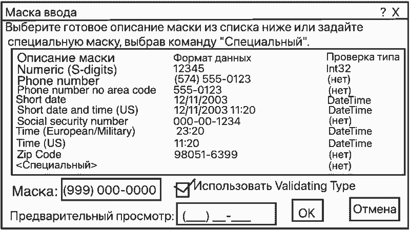

Рис. 11.1. Список готовых масок.

Для извлечения отформатированного в соответствии с маской значения используйте свойство `Text`. Перед применением считанного значения можно проверить его на соответствие типу и величине. Это — отсроченные по времени проверки. Оперативно, то есть не покидая поле, эти проверки можно выполнить в обработчике события `TypeValidationCompleted` (см. ниже). **С помощью маски** (свойство `Mask`) можно задать следующие типы входных данных: **во-первых**, требуемые входные символы; **во-вторых**, необязательные входные символы; **в-третьих**, литералы маски или символы, которые должны непосредственно отображаться в текстовом поле MaskedTextBox, например дефисы (-) в номере телефона или знак денежной единицы в цене; **в-четвертых**, тип входных данных, ожидаемых в заданной позиции маски, например цифра, буква или алфавитно-цифровой символ. Также может быть задана специальная обработка для входных символов, например преобразование букв в верхний или нижний регистр. **Маска**, задаваемая свойством `Mask`, должна быть строкой, состоящей из одного или нескольких элементов маски, как показано в таблице 11.1.

Страница 98

### Элементы маски и их описание Таблица 11.1 ,

| Элемент маски | Описание |
| --- | --- |
| 0 | Любая одиночная цифра от 0 до 9. Это обязательная для ввода цифра. |
| 9 | Цифра или пробел, необязательный символ. |
| $ \# $ | Цифра или пробел, необязательный символ. Если эта позиция в маске пуста, в свойстве Text она будет представлена пробелом. Допускаются знаки плюса ($+$) и минуса ($-$). |
| L | Буква, необходимый символ. Ограничивает вводимые данные наборами букв ASCII от а до z и от А до Z. Этот элемент маски аналогичен регулярному выражению [a-zA-Z]. |

Страница 99

[output not shown]

| Элемент маски | Описание |
| --- | --- |
| . | Символ десятичного разделителя. |
| , | Символ разделителя групп разрядов. |
| : | Символ разделителя компонентов времени. |
| / | Символ разделителя компонентов даты. |
| $ | Символ денежной единицы. |

[output not shown]

Страница 100

Когда элемент управления `MaskedTextBox` отображается во время выполнения, маска в нем представляется в виде последовательности символов приглашения и дополнительных литералов. **Например**, в маске `(000)-000-0000` символы '0' являются символами приглашения, а символы '(', ')' и '-' — дополнительными литералами. Литералы всегда занимают статическую позицию в маске, и пользователь не может перемещать или удалять их. Символы приглашения доступны для изменения и представляют обязательный или необязательный входной символ. **Десятичный разделитель** (.), разделитель тысяч (,), времени (:), даты (/) и символы валют ($$$) по умолчанию отображаются в соответствии с языком и региональными параметрами, установленными для приложения. Например, для маски `00/00/0000` правильным форматом даты для России будет `дд.мм.гггг`, а для США — `mm/dd/yyyy`. **Можно принудительно** отображать другие символы приглашения, используя свойство `FormatProvider`. Пользователи могут перемещаться по маске, используя клавиши со стрелками влево и вправо или курсор мыши, а ввод пробела позволяет пропустить необязательные позиции в маске.

| Примеры масок: | ... |
| --- | --- |
| `00/00/0000` | - день, месяц числом и год в формате текущего региона. |
| `00->L<LL-0000` | — день, сокращенное наименование месяца (3 буквы) и год в формате США. Сокращенное наименование месяца, отображается с начальной прописной буквой, за которой следуют две буквы в нижнем регистре. |
| `(999)-000-0000` | — номер телефона и код города. Код города необязателен. |

Страница 101

Чтобы не вводить необязательные символы, пользователь может ввести вместо них пробелы или переместить указатель мыши в позицию маски, представленную первой цифрой 0.

[output not shown]

Вставка символов в маску во время выполнения управляется свойством `InsertKeyMode`. Чтобы указать нестандартный символ приглашения, можно использовать свойство `PromptChar`. Свойство `HidePromptOnLeave` определяет, остаются ли видны пользователю символы приглашения, если фокус ввода покидает элемент управления. **Когда пользователь вводит** данные в текстовое поле с маской, допустимые входные символы последовательно занимают место символов приглашения. Если пользователь вводит недопустимый символ, позиция в маске не замещается, подается звуковой сигнал (если свойство `Веер` имеет значение `true`) и вызывается событие `MaskInputRejected`. Путем обработки этого события можно реализовать собственную логику обработки ошибок. **Литералы при вводе** допустимого символа автоматически пропускаются. Для перемещения к следующей или предыдущей позиции можно использовать клавиши со стрелками, `Пробел` (`Space`) или `Backspace`. Также для перемещения вправо можно использовать символ приглашения.

Свойство `MaskFull` позволяет определить, введены ли пользователем все необходимые символы. Это свойство можно использовать в обработчике события `MaskInputRejected`, чтобы определить, были ли вводимые пользователем данные отклонены из-за того, что в маске не осталось позиций для ввода. **Чтобы определить**, были ли введены только необходимые элементы, используйте свойство `MaskCompleted`. **Свойство** `Text` всегда будет извлекать введенные пользователем данные, отформатированные согласно маске и значению свойства `TextMaskFormat`, которое получает или задает значение, определяющее, включаются ли в свойство Text только литералы, только символы приглашения или символы обеих категорий. Если символы приглашения не включаются, они преобразуются в пробелы в форматированной строке. **Использование масок** не всегда гарантирует, что вводимые пользователем данные окажутся допустимым значением для заданного типа. В следующем коде показана маска: `maskedTextBox1.Mask = "00/00/0000";` **Эта маска требует**, чтобы пользователь ввел восемь цифр, но она не может проверить, что пользователь ввел значения месяца, даты и года в допустимом диапазоне. Для этой маски одинаково приемлемы строки "20.12.2020" и "70.70.0000".

Страница 102

С помощью свойства ValidatingType можно задать, какому типу должно соответствовать вводимое значение. Для даты и/или времени свойству `ValidatingType` необходимо присвоить объект `System.Type` типа `DateTime`. Пример: `maskedTextBox1.ValidatingType = typeof(DateTime);` **Если свойству** `ValidatingType` присвоено значение, то после завершения синтаксического анализа текстового поля `MaskedTextBox` (с помощью метода `Parse`) возникает событие `TypeValidationCompleted`. Это событие происходит, когда пользователь переключает фокус из элемента управления `MaskedTextBox` на другой элемент. Обработчик этого события позволяет узнать, как завершилась проверка значения.

**Обработчику события TypeValidationCompleted** передается параметр `e` типа `TypeValidationEventArgs`. Приведем наиболее значимые события этого параметра:

- **IsValidInput** — получает значение, указывающее, было ли успешно выполнено преобразование входной строки в тип, заданный свойством `ValidatingType`.
- **ReturnValue** - получает объект (`object`), являющийся результатом преобразования отформатированной ВХОДной строки. Значение свойства `ReturnValue` параметра `TypeValidationEventArgs` можно использовать после успен ной проверки поля на соответствие заданному типу.
- **Cancel** — возвращает или задает значение, показывающе, следует ли отменить данное событие. Значение `true` отменяет событие и удерживает фокус в элементе управления `MaskedTextBox`. По умолчанию `e.Cancel = false`.

Страница 103

**Пример**. В следующем примере кода элемент управления `MaskedTextBox` инициализируется так, чтобы принимать дату. Для примера создано приложение, на форму которого добавлен элемент управления `MaskedTextBox` и кнопка, которая необходима для переключения фокуса ввода. В программе используются событие `TypeValidationCompleted`, чтобы оповестить пользователя о вводе недопустимых данных. Оповещение об ошибке выводится с помощью компонента `ТооТір`, описанного во втором томе данного учебника.

```
ToolTip toolTip1 = new ToolTip();
private void Form1_Load(object sender, EventArgs e)
{
    maskedTextBox1.Mask = "00/00/0000" ;
    // Определим тип для проверки поля даты.
    maskedTextBox1.ValidatingType = typeof(DateTime);
    // Подключим обработчик события Type ValidationCompleted
    maskedTextBox1.TypeValidationCompleted += maskedTextBox1_TypeValidationCompleted;
    toolTip1.IsBalloon = true;
    toolTip1.ToolTipTitle = "Неверная дата";
    toolTip1. ToolTipIcon = ToolTipIcon.Error;
}
```

Страница 104

```
private void maskedTextBox1_TypeValidationCompleted(object sender, TypeValidationEventArgs e)
{
    // Если поле не изменено, то выход.
    if (maskedTextBox1.Text == " . .") return;
    // Прошло ли проверку значение на соответствие Date Time?
    if (!e.IsValidInput)
    {
        maskedTextBox1.KeyDown += maskedTextBox1_KeyDown;
        toolTip1.Show(
            "Дата должна быть введена в формате дд.мм.гггг."
            , maskedTextBox1, 0, -75, 6000
        );
        e.Cancel = true;
    }
    else
```

```
    {
        // Теперь, когда дата прошла проверку на соответствие
        // базовому типу, выполните более конкретные проверки.
        if ((DateTime)e.ReturnValue < DateTime.Now)
        {
            maskedTextBox1.KeyDown += maskedTextBox1_KeyDown;
            toolTip1.Show(
                "Дата в этом поле должна быть "
                + "больше сегодняшней даты."
                , maskedTextBox1, 0, -80, 6000
            );
            e.Cancel = true;
        }
    }
}
```

Страница 105

```
void maskedTextBox1_KeyDown(object sender, KeyEventArgs e)
{
    // Всплывающая подсказка видна в течение шести секунд
    // Свернем подсказку, если пользователь вводит
    // какие-либо данные.
    toolTip1.Hide(maskedTextBox1);
    maskedTextBox1.KeyDown -= maskedTextBox1_KevDown;
}
```

В данном примере обработчик события `maskedTextBox1_KeyDown` подключается только в случае ошибки и отключает после ввода первого символа в поле. Данный код в случае неверного формата даты выводит окно, представленное на рис. 11.2.

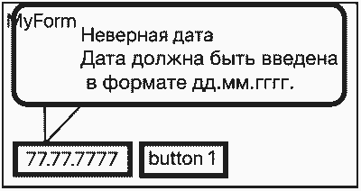

Рис. 11.2. Окно с сообщением об ошибке ввода в поле с маской

После завершения обработчика события `TypeValidationCompleted` вызывается стандартное событие проверки `Validating`, поэтому событие `TypeValidationCompleted` не так уж и важно — все проверки можно выполнить в обработчике события `Validating`. Если Вы не знаете, как ввести правильную дату, и программа из-за неверного значения не может завершиться, то очистите поле с маской, выделив его и нажав клавишу `Delete`.

Страница 106-107

# 12. ГРУППИРОВАНИЕ ЭЛЕМЕНТОВ.

Размещая элементы управления на форме, разработчик добавляет их в контейнер этой формы. Однако форма может содержать элементы управления, которые также являются контейнерами. К числу таких контейнеров относятся элементы управления `GroupBox` (рамка) и `Panel` (панель). Существуют и другие контейнеры.

# 12.1. Элемент управления GroupBox.

Элемент управления GroupBox отображается в виде рамки с необязательным заголовком. В рамку помещают элементы управления, которые образуют группу. Как правило, с помощью `GroupBox` создают группу переключателей `RadioButton`. Иногда с эргономической целью рамку рисуют вокруг других элементов управления. На рис. 12.1 показано несколько элементов управления, помещенных в рамку. **Особенность контейнера** `GroupBox` состоит в том, что действия, выполняемые с контейнером, распространяются на всё его содержимое. Например, для того чтобы сделать все элементы управления контейнера неактивными, достаточно сделать неактивным их контейнер, например: `groupBox1.Enabled = false;` **Чаще всего** в программе никаких действий с элементами управления `GroupBox` не выполняется. **Объект** `GroupBox` не предназначен для отображения полос прокрутки. Если необходим схожий элемент управления с полосой прокрутки, используйте элемент управления Panel.

Страница 108

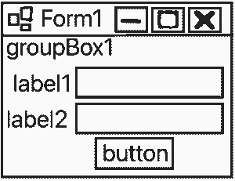

Рис. 12.1. Рамка с элементами управления (Комментарий от пользователя. Group Box один имеет вид серой рамки и в качестве дочерних объектов содержит лэйбл один, лэйбл 2, Text Box один, Text Box два и кнопку.)

# 12.2. Элемент управления Panel.

Элемент управления `Panel` (панель) представляет собой рамку без заголовка. Кроме того, элемент управления `Panel` по умолчанию отображается без границ. Это позволяет сделать из панели невидимую кнопку. Свойство `BorderStyle` отображает стандартную или трехмерную границу панели. **Поскольку элемент** управления `Panel` выводится из класса `ScrollableControl`, то с помощью свойства `AutoScroll` в элементе управления `Panel` можно включить полосы прокрутки. Если свойство `AutoScroll` имеет значение `true`, все элементы управления, расположенные в панели, можно прокручивать с помощью присутствующих полос прокрутки. **В остальном многое**, что было сказано выше об элементе управления `GroupBox`, справедливо и для `Panel`.

Страница 109

# 13. ФЛАЖКИ И ПЕРЕКЛЮЧАТЕЛИ

### 13.1. Элемент управления CheckBox

Флажок «да»

Флажок «нет»

Флажок «да»

Флажок «нет»

(В HTML состояние Checkbox неопределён не бывает. В C# состояние Checkbox неопределён бывает.)

Комментарий от читателей. В markdown можно и так: `- [ ]`, `- [x]`. Вот как оно работает, пример:

- Флажок «нет»
- Флажок «да»

**Названия состояний условны** — какой смысл будет иметь то или иное состояние, определяет разработчик. Например, тремя состояниями можно отметить состояние символов в слове: все прописные; все строчные; строчные и прописные.

Страница 110

Элемент управления `CheckBox` имеет множество свойств, методов и событий. Большинство из них совпадают с аналогичными для `Button`. Есть и свои уникальные члены. Свойство **Appearance** определяет, отображается ли элемент управления `CheckBox` в качестве обычного элемента управления `CheckBox` (по умолчанию) или как кнопка `Button`. В последнем случае состояния флажка отмечается другим цветом. Для того чтобы установить или прочитать состояние флажка с двумя состояниями, используется свойство `Checked`, которое может иметь значение либо `true`, либо `false`: `if ( checkBox1.Checked ) {/*...*/}`. **Для флажка с тремя состояниями** используется свойство `CheckState`. Это свойство может принимать одно из следующих значений: Checked — элемент отмечен; Unchecked — элемент не отмечен; Indeterminate — элемент не доступен. **Если для свойства** `ThreeState` задано значение `true`, свойство `Checked` будет возвращать значение `true` как для отмеченного флажком, так и для неопределенного состояния. На практике в основном используются **два подхода к работе с флажками_. __Во-первых**. Пользователь сначала устанавливает все флажки, а затем нажимает какую-то кнопку и в её обработчике осуществляется чтение состояний флажков. **Во-вторых**: для фиксации смены состояния флажка для него создаётся обработчик события CheckedChanged, которое является событием по умолчанию. Обработчик получает управление, если состояние флажка изменилось. Пример обработчика:

```
private void checkBox i_ CheckedChanged (object sender, EventArgs e)
{ if (checkBox1.Checked) { /* Флажок установлен. */ } else { /* Флажок сброшен. */ } }
```

Страница 111

Примечание. В строках, отмеченных точками, должен находиться соответствующий код. **Можно использовать** один обработчик на все флажки, но тогда нужно будет анализировать первый параметр обработчика, например:

```
private void checkBox1_CheckedChanged(object sender, EventArgs e)
{
    if (((Control)sender).Name == "checkBox1")
    {
        // Здесь должен быть код для проверки состояния checkBox1.
    }
    else
    {
        if (((Control)sender).Name == "checkBox2")
        {
            // Здесь должен быть код для проверки
            // состояния checkBox2.
        }
        else
        {
            // Здесь должен быть код для проверки состояния
            // последнего флажка.
        }
    }
}
```

Комментарии читателей. Допустимо использовать if else без фигурных скобочек в случае тела ветвлений из одного оператора. Будьте добросовестны, не допускайте путаницы, ставьте фигурные скобочки всегда. Да прибудет бог культа машин с вами.

Страница 112

# 13.2. Элемент управления `RadioButton`

Элемент управления `RadioButton` называется переключателем. На форме, как правило, используются два или более переключателей, образующих группу (см. рис. 13.3). Каждый переключатель группы представляет взаимоисключающий вариант выбора. Переключатель может находиться в одном из двух состояний: выключен (Checked = false) или включен (Checked = true).

- Переключатель 1
- Переключатель 2
- Переключатель 3

Рис. 13.3. Пример группы переключателей.

В группу должны быть объединены зависимые переключатели. Чтобы создать на форме группу или несколько групп переключателей, поместите каждую группу в собственный контейнер, такой как `GroupBox` или `Panel`. Все элементы управления `RadioButton`, не входящие в указанные (и другие) контейнеры, составляют группу контейнера формы. **На рис. 13.4** показаны две группы переключателей, находящиеся в контейнерах `GroupBox`. В группе пользователь может выбрать и тем самым включить только один переключатель. Рекомендуется на этапе визуальной разработки в окне свойств один из переключателей группы сделать включенным по умолчанию. При выборе пользователем какого-либо выключенного переключателя группы он включается (появляется точка в кружке), а ранее включенный переключатель этой группы автоматически отключается. Элементы управления `RadioButton` и `CheckBox` имеют аналогичные функции, они позволяют пользователю выбрать вариант или отменить выбор. Разница заключается в том, что несколько элементов управления `CheckBox` можно выбрать одновременно, а элемент `RadioButton` — только один в группе.

Страница 113

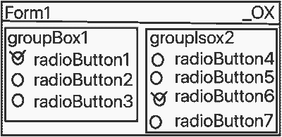

Рис. 13.4. Две группы переключателей, объединённые контейнерами.

Чтобы получить или задать состояние элемента RadioButton, используйте свойство Checked. Основным событием переключателя, как и флажка, является CheckedChanged. Техника работы с переключателями остается практически такой же, как и с флажками. Но объем работы снижается, так как после определения установленного переключателя, остальные переключатели группы можно не анализировать. Пример. В приведенном ниже фрагменте программы осуществляется поиск первого включенного переключателя контейнера groupBox1. Предполагается, что группа, кроме флажков, может включать и другие элементы управления, поэтому выполняется анализ типа элемента управления.

```
foreach (var item in groupBox1.Controls)
{
    if (item is RadioButton)
    {
        RadioButton rb = (RadioButton)item;
        if (rb.Checked)
        {
            txt = rb.Text;
            // Выполним требуемые действия для данного переключатели.
            break;
            // В группе только один включенный переключатель.
        }
    }
}
```

Страница 114

В примере свойство `Controls` элемента `GroupBox` возвращает коллекцию элементов управления, включенных в группу. Если бы контейнер содержал только переключатели, то код стал бы проще.

Страница 115

# 14. РЕГУЛЯТОРЫ.

К регуляторам, описываемым ниже, относятся элементы управления `DomainUpDown` и `NumericUpDown`.

# 14.1. Элемент управления DomainUpDown.

По сравнению с элементом управления `ComboBox`, достоинством `DomainUpDown` является его сверхкомпактное представление. Но в этом заключается и недостаток. Рекомендуется перед использованием списка отсортировать его в алфавитном порядке. Это облегчит пользователю поиск нужной строки. Для выполнения сортировки необходимо свойству `Sorted` присвоить значение `true`. Это свойство доступно в окне «Свойства». **Другими полезными свойствами**, доступными в окне «Свойства», являются `Text`, `Items`, `ReadOnly` и `Wrap`.

- Свойство **Text** — получает или задает текст, отображаемый в текстовом поле регулятора. Этого свойства достаточно для решения большинства задач.
- Свойство **Items** содержит список строк, которые перебираются в элементе управления.

Страница 116

Пользователь может вводить в элемент управления свой текст, если свойство `ReadOnly` имеет значение `false`. Значение `true` разрешает пользователю нажимать лишь кнопки «стрелка вверх» и «стрелка вниз», благодаря чему выбор возможен лишь из числа предопределенных значений. **Если для свойства** `Wrap` задано значение `true`, список закольцовывается, то есть при прокрутке после последней строки списка выводится первая и наоборот. **В коде программы** разработчик может использовать следующие свойства и методы: **Свойство** `SelectedIndex` — получает или задает значение индекса для выделенного элемента. Если элемент не выбран, индекс равен -1. **Свойство** `SelectedItem` — получает или задает текстовое представление выделенного элемента, основываясь на значении индекса элемента, выделенного в коллекции. Если элемент не выбран, `SelectedItem` возвращает `null`. **Если пользователю** разрешен ввод текста в поле, то нужно понимать, что для введенного вручную текста `SelectedIndex=-1`, `SelectedItem=null`, a `Text !=""`. Такие условия позволяют отличить выбранную строку от введенной.

Страница 117

**Индексатор** коллекции `Items` — получает или задает элемент по указанному целочисленному индексу в коллекции. Метод **UpButton** — отображает предыдущий элемент в коллекции. Метод **DownButton** — отображает следующий элемент в коллекции объектов. **Создать коллекцию объектов**, отображаемых в элементе управления `DomainUpDown`, можно или программным способом, например с помощью метода `Items.Add`, или в окне «Свойства» с помощью редактора коллекции строк, вызываемого через свойство `Items`. **Пример**. Создадим форму со списком, представленным элементом управления DomainUpDown. Перетащим на форму элемент управления DomainUpDown и в окне его свойств выберем Items. Откроем редактор коллекции строк и введем названия городов (см. рис. 14.2).

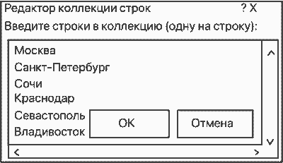

Рис. 14.2. Окно редактора коллекции строк.

Нажмём «ОК» и в окне «Свойства» сделаем следующие установки:

```
private void button1_Click(object sender, EventArgs e)
{
    if(domainUpDown1.Text == "<Выберите город>")
    { MessageBox.Show("Вы не выбрали или не ввели название города"); }
    else { MessageBox.Show(domainUpDown1.Text);}
}
```

Если в коллекцию программным способом добавляется объект, отличный от `string`, то вызывается метод `ToString` для представления объекта в текстовом виде.

Страница 118